# [Blog home](http://rajeshrinet.github.io/blog)

## Active colloids

Colloids - particles of sizes between few nanometers to several microns - usually suspended in a fluid medium

- Colloids are small enough to exhibit Brownian motion, and yet, large enough to be studied using microscopes
- Einstein and Perrin showed that the Brownian motion of colloidal particles is a striking proof of the ‘graininess’ of the ambient fluid, and thus confirmed the molecular nature of matter.
- Colloids are also used as analogs of ‘atoms’ - used to understand fundamental concepts of condensed matter like metastability, topological defects, etc.

Active colloids - a new class of colloids which create flow, even when stationary, due to large surface gradients from local nonequilibrium processes (like chemical reactions)

- The surface gradients may also lead to self-propulsion when the spatial symmetry is broken
- These are, then, new kinds of ‘atoms’ - display novel structures with no analog in passive colloidal suspensions
- equilibrium concepts do not apply - entropy production, rather than entropy, determines steady-state

Since microorganisms also create flow when stationary and are capable of self-propulsion, they belong to the same category of synthetic microswimmers (Ebbens and Howse, Soft Matter 2010), and self-propelling droplets (Thutupalli et al, NJP 2011). While synthetic microswimmers usually self-propel due to chemical asymmetry, self-propulsion of the droplets is due to spontaneous symmetry breaking.

To summarize, the main features of active colloids are

- Nonequilibrium processes in a thin layer of surface drive exterior flow, even when the colloid is stationary
- The fluid stress may react back and cause self-propulsion in absence of external forces or torques
- Fluid flow mediates long-range hydrodynamic interactions (HI)
- Similar collective behaviour in distinct active colloidal system

### Ideal active colloid

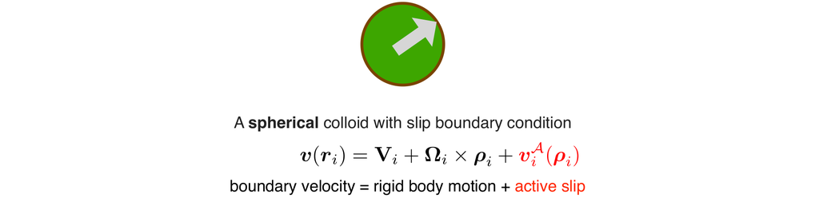

#### Active slip

- activity is represented by slip on a spherical surface
- slip is a mechanism to drive exterior flow without rigid body motion
- slip-induced flow may also cause self-propulsion without external forces or toques
- flow is a unique function of slip and thus universal features are isolated
- problem reduced to obtaining force per unit area given the slip

### Equations of motion

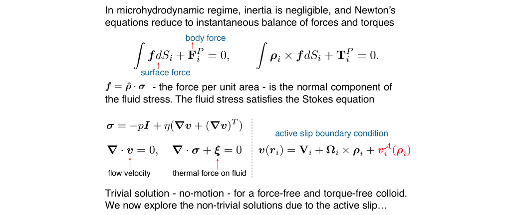

A detailed derivation of the force per unit area is given in [arXiv:1603.05735](https://arxiv.org/abs/1603.05735). To outline the main steps:

- Use the boundary-domain integral representation of Stokes flow
- Expand the slip and force per unit area in tensorial spherical harmonics, defined as, $$\mathbf{Y}^{(l)}(\boldsymbol{\hat{\rho}})=(-1)^{l}\rho^{l+1}\boldsymbol{\nabla}^{(l)}\rho^{-1}, \text{where } \boldsymbol{\nabla}^{(l)}=\boldsymbol{\nabla}_{\alpha_{1}}\dots\boldsymbol{\nabla}_{\alpha_{l}}, $$
- Express the coefficients of the force per unit area and the slip as sum of irreducible tensors
- The key idea, then, is to Taylor expand the Green's function about the center of the sphere, express the $l$-th degree polynomial of the radius vector in terms of $\mathbf{Y}^{(l)}$s, and use their orthogonality and biharmonicity of the Green’s function.
- Solve the resulting linear system of equations to obtain the forcer per unit area in terms of the slip. We call the linear relations between the irreducible coefficients of the force per unit area and the slip - the generalized Stokes laws.

### Generalized Stokes laws

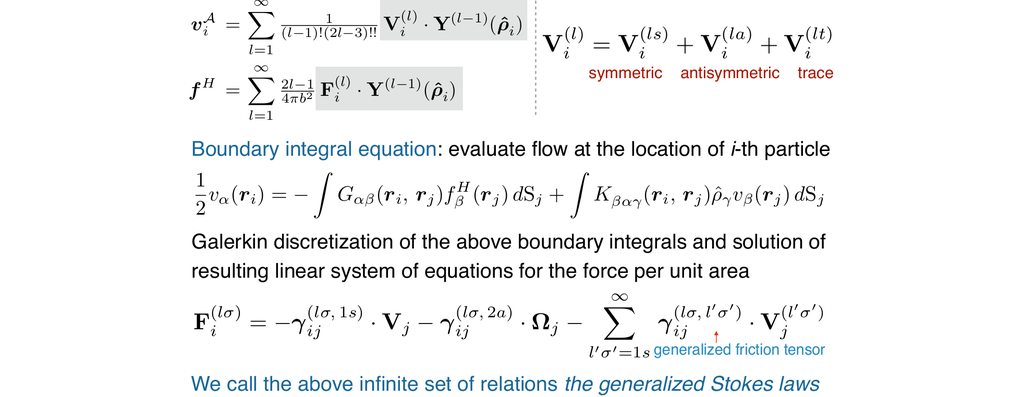

The best-known special case of the generalized Stokes laws is the Stokes law for translation $F=-6\pi\eta b V$, where $b$ is the radius of the colloids and $\eta$ is the viscosity of the fluid. The linear relations between the modes of the slip and the force per unit area is obtained in terms of the generalized frictions tensors ($\boldsymbol{\gamma}^{(l'\sigma',\,l\sigma)}$). The generalized friction tensors are obtained in terms of a Green's function of Stokes flow, and thus the solution is applicable to an arbitrary geometry of Stokes flow.

The net hydrodynamic force and torque on a colloid follow from the first two irreducible coefficients of the force per unit area and are obtained from the generalized Stokes laws. These are then used in Newton's laws to derive the Langevin description of active colloids.

### Langevin equations and propulsion tensors

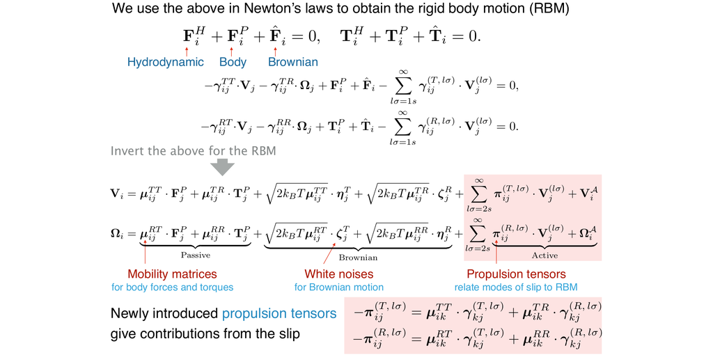

Thus, the rigid body motion of active colloids is obtained in terms of the familiar mobility matrices and the newly introduced propulsion tensors. These tensors are many-body in nature and are obtained in terms of a Green's function of Stokes equation. Their numerical computation is essential to simulate a system of many active colloids.

To this end, these Langevin equations have been implemented in a numerical library - [PyStokes](https://github.com/rajeshrinet/pystokes). PyStokes is a Cython library to simulate the motion of spherical active colloids and to compute external flow field produced by them. The development of PyStokes codebase happens on [GitLab](https://gitlab.com/rajeshrinet/pystokes), while a stable, well-documented, free, and open-source version is available on [GitHub](https://github.com/rajeshrinet/pystokes). PyStokes can be used to simulate experimentally realizable systems of active colloids to derive testable predictions. Detailed examples of usage of the library are available on [GitHub](https://github.com/rajeshrinet/pystokes/tree/master/pystokes).

To summarize, we have developed a complete microscopic theory of active colloidal suspensions. The results are then used to study the interplay of activity, hydrodynamic interactions, and external potentials in active colloidal suspensions. In particular, we have shown in a recent [work](https://arxiv.org/abs/1710.10300), that flow and collective dynamics of active colloids are determined by the boundaries in the domain of the flow. The collective steady-states of momentum-conserving active matter systems are characterized using the flow-induced phase separation (FIPS) mechanisms. These are of dynamical origin and obtained from the balance of forces and torques. Since active forces and torques on colloids are modified qualitatively and quantitatively by the presence of boundaries in the flow, new collective phenomena of active colloids appear in different geometries of Stokes flow. In another [work](https://arxiv.org/abs/1610.06528), we have derived the FIPS mechanisms of active crystallization, observed in experiments of microorganisms (Petroff et al, PRL 2015) and synthetic microswimmers (Palacci et al, Science 2013) at a plane wall.

### Summary

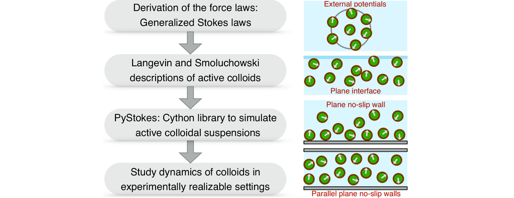